# SydneyEnergyResearch

Electricity

© University of Sydney 2023

30/03/2023

Taking a quick view of the data

```r
# For the 2019 data set
dim(data2019)
```

```
## [1] 39 17
```

```r
head(data2019, 10)
```

```
## # A tibble: 10 × 17
##    ...1  ...2  ...3  ...4  ...5  ...6  ...7  ...8  ...9  ...10 ...11 ...12 ...13
##    <chr> <chr> <chr> <chr> <chr> <chr> <chr> <chr> <chr> <chr> <chr> <chr> <chr>
##  1 <NA>  <NA>  <NA>  <NA>  <NA>  <NA>  <NA>  <NA>  <NA>   <NA> <NA>  <NA>   <NA>
##  2 Loca… Resi… <NA>  <NA>  <NA>  <NA>  <NA>  Solar <NA>   <NA> <NA>  <NA>  "Non…
##  3 <NA>  Dail… MWh   <NA>  <NA>  Cust… <NA>  Numb… <NA>  "Gen… <NA>  Ener… "MWh"
##  4 <NA>  <NA>  Gene… Off … Total Off … Total Res   Non-… "Res… Non-… <NA>   <NA>
##  5 BAYS… 12.4… 2756… 2947… 3051… 1552… 6697… 2842  190   "917… 3900… 5848… "136…
##  6 BURW… 12.8… 6442… 3814… 6824… 2241… 1455… 684   35    "222… 631.… 1434… "414…
##  7 CANA… 13.4… 1784… 8682… 1870… 5259… 3805… 1601  85    "588… 3572… 3427… "678…
##  8 CANT… 15.2… 6444… 8135… 7258… 3701… 1299… 9947  561   "320… 1613… 2038… "231…
##  9 CENT… 16.4… 7375… 1699… 9074… 8133… 1510… 21015 674   "754… 1918… 5525… "222…
## 10 CESS… 18.9… 1451… 2206… 1671… 1076… 2412… 4329  204   "194… 4744… 1192… "431…
## # … with 4 more variables: ...14 <chr>, ...15 <chr>, ...16 <chr>, ...17 <chr>
```

```r
# For the 2020 data set
dim(data2020)
```

```
## [1] 41 17
```

```r
head(data2020, 10)
```

```
## # A tibble: 10 × 17
##    ...1  ...2  ...3  ...4  ...5  ...6  ...7  ...8  ...9  ...10 ...11 ...12 ...13
##    <chr> <chr> <chr> <chr> <chr> <chr> <chr> <chr> <chr> <chr> <chr> <chr> <chr>
##  1 Regi… Loca… Resi… <NA>  <NA>  <NA>  <NA>  <NA>  Solar <NA>   <NA> <NA>  <NA>
##  2 <NA>  <NA>  Dail… MWh   <NA>  <NA>  Cust… <NA>  Numb… <NA>  "Gen… <NA>  Ener…
##  3 <NA>  <NA>  <NA>  Gene… Off … Total Off … Total Res   Non-… "Res… Non-… <NA>
##  4 Sydn… BAYS… 12.4  2778… 28618 3064… 15314 67909 3134  212   "113… 4871  7584
##  5 <NA>  BURW… 12.6  63676 3638  67314 2196  14600 753   38    "273… 674   1696
##  6 <NA>  CANA… 13.3  1778… 8305  1861… 5075  38223 1805  99    "729… 3950  4406
##  7 <NA>  CANT… 15.1  6416… 79006 7206… 36476 1310… 10900 631   "389… 17862 26313
##  8 <NA>  CUMB… 13.1  1019… 8697  1106… 4027  23149 1908  129   "619… 4167  4519
##  9 <NA>  GEOR… 14.6  2699… 39761 3097… 19182 58079 4351  181   "159… 3850  9931
## 10 <NA>  HORN… 18.2  3013… 49437 3507… 20861 52676 6789  180   "282… 4519  16246
## # … with 4 more variables: ...14 <chr>, ...15 <chr>, ...16 <chr>, ...17 <chr>
```

```r
# For the 2023 data set
dim(data2023)
```

```
## [1] 41 17
```

```r
head(data2023, 10)
```

```
## # A tibble: 10 × 17
##    ...1  ...2  ...3  ...4  ...5  ...6  ...7  ...8  ...9  ...10 ...11 ...12 ...13
##    <chr> <chr> <chr> <chr> <chr> <chr> <chr> <chr> <chr> <chr> <chr> <chr> <chr>
##  1 Regi… Loca… Resi… <NA>  <NA>  <NA>  <NA>  <NA>  Solar <NA>   <NA> <NA>  <NA>
##  2 <NA>  <NA>  Dail… MWh   <NA>  <NA>  Cust… <NA>  Numb… <NA>  "Gen… <NA>  Ener…
##  3 <NA>  <NA>  <NA>  Gene… Off … Total Off … Total Res   Non-… "Res… Non-… <NA>
##  4 Sydn… BAYS… 12.6… 2882… 2733… 3155… 14792 68610 4381  279   "211… 6862… 1605…
##  5 <NA>  BURW… 12.4… 6441… 3376… 6779… 2101  14861 995   52    "469… 988.… 3398…
##  6 <NA>  CANA… 13.5… 1830… 7881… 1909… 4765  38740 2490  117   "131… 4284… 9463…
##  7 <NA>  CANT… 15.0… 6567… 7574… 7325… 35055 1334… 14679 823   "696… 2682… 5498…
##  8 <NA>  CUMB… 12.8… 1012… 8201… 1094… 3853  23410 2550  179   "115… 6067… 9777…
##  9 <NA>  GEOR… 14.6… 2772… 3853… 3157… 18522 59056 6046  234   "307… 6387… 2171…
## 10 <NA>  HORN… 18.4… 3095… 4985… 3594… 20435 53315 9222  222   "495… 6107… 3195…
## # … with 4 more variables: ...14 <chr>, ...15 <chr>, ...16 <chr>, ...17 <chr>
```

## 0.1 Data source verification

This data source is from Ausgrid, which is a large electricity provider that has more than 1.7 million customers in Sydney, Australia.Although this is a electricty provider that is run by a company, however, it must be subjected to a range of regulations and guidelines to ensure the accuracy of their data, including the Australian Energy Regulator(AER), according to the Australian energy policies.

Some useful functions

```r
filter_int <- function(data){
  integers <- as.numeric(grep("\\d+", data, value = TRUE))
  max_index <- which(integers == max(integers))
  return(integers[-max_index])
}
ex_cwords <- function(words) {
  capital_words <- words[str_detect(words, "^([A-Z]+)$")]
  return(capital_words)
}
wrap.it <- function(x, len)
{
  sapply(x, function(y) paste(strwrap(y, len),
                              collapse = "\n"),
         USE.NAMES = FALSE)
}

wrap.labels <- function(x, len)
{
  if (is.list(x))
  {
    lapply(x, wrap.it, len)
  } else {
    wrap.it(x, len)
  }
}
```

## 0.2 Research question 1:

The impact of the covid-19 pandemic on electricity consumption in the different suburbs of Sydney As covid-19 strikes Australia, our reliance on digital equipments especially remote streaming apps has increased drastically.So, the hypothesis is the usage of digital equipments has led to a increase in electricity consumption. Is there an electricity usage rise during the pandemic?

## 0.3 IDA

To get an idea of the new data, we will do a quick bargraph of the ‘general supply’ columns from the excel file. (It is with several trial and error, that we have found out the original excel file is not suitable for R data analysis, therefore manual excel operation was done to extract it out into a form which was useful.)

```r
library(readxl)
library(dplyr)
```

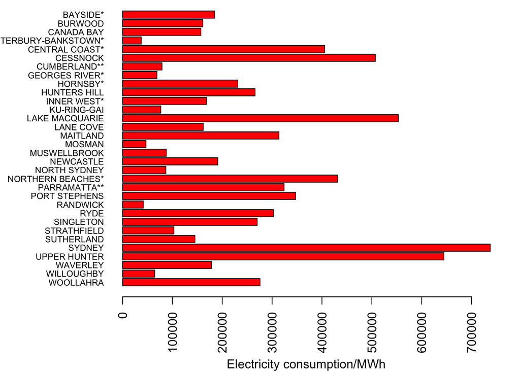

```r
options(scipen = 999)

# Read in files
extracted_data <- read_excel("data/Electricity_consumption(extracted).xlsx")
extracted_data <- arrange(extracted_data)

# Setting up the output graph
par(mar = c(5, 8, 0, 2), mgp = c(4, 1, 0))

# The 2019 Dataset
values2019 <- extracted_data$`2019-R`
suburbs2019 <- extracted_data$H2019
barplot(values2019, names.arg=wrap.labels(rev(suburbs2019), 20),
        col="red", xlab=" Electricity consumption/MWh", horiz=T, las=2, cex.names = 0.7)
```

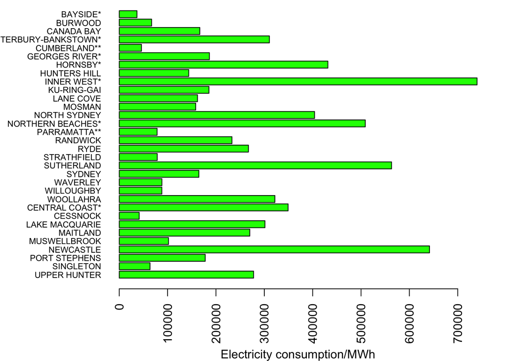

```r
# The 2020 Dataset
values2020 <- extracted_data$`2020-R`
suburbs2020 <- extracted_data$H2020
barplot(values2020, names.arg=wrap.labels(rev(suburbs2020), 20),
        col="green", xlab=" Electricity consumption/MWh", horiz=T, las=2, cex.names = 0.7)
```

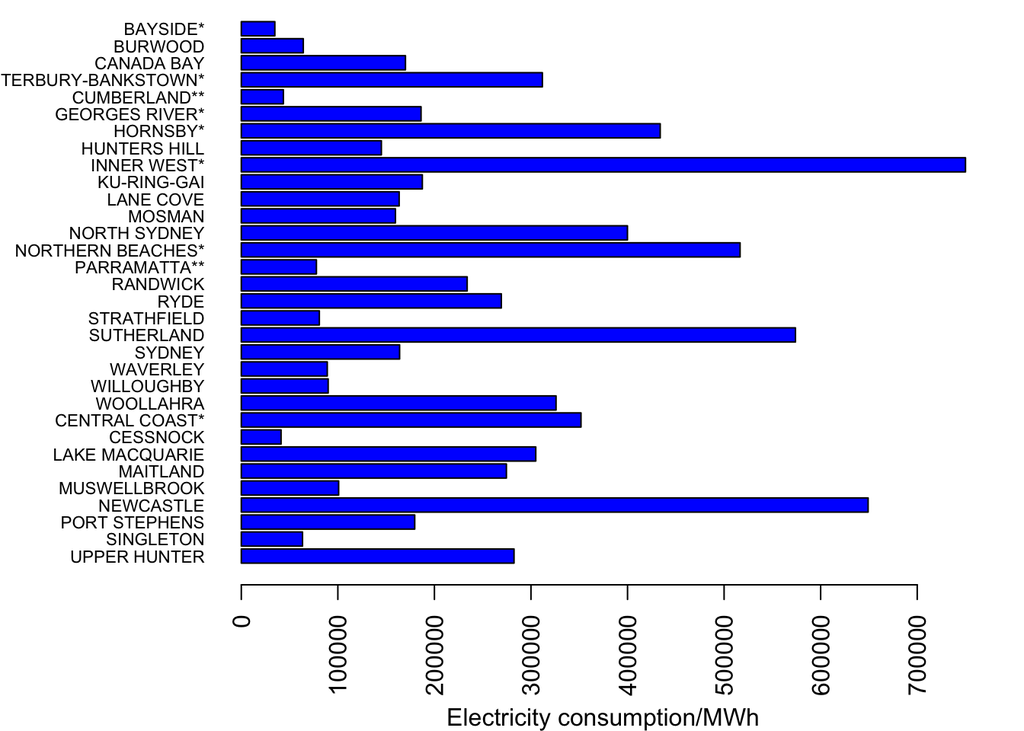

```r
# The 2021 Dataset
values2021 <- extracted_data$`2021-R`
suburbs2021 <- extracted_data$H2021
barplot(values2021, names.arg=wrap.labels(rev(suburbs2021), 20),
        col="blue", xlab=" Electricity consumption/MWh", horiz=T, las=2, cex.names = 0.7)
```

It seems like the data itself is not distinctive enough to be able figure out the difference from first site.

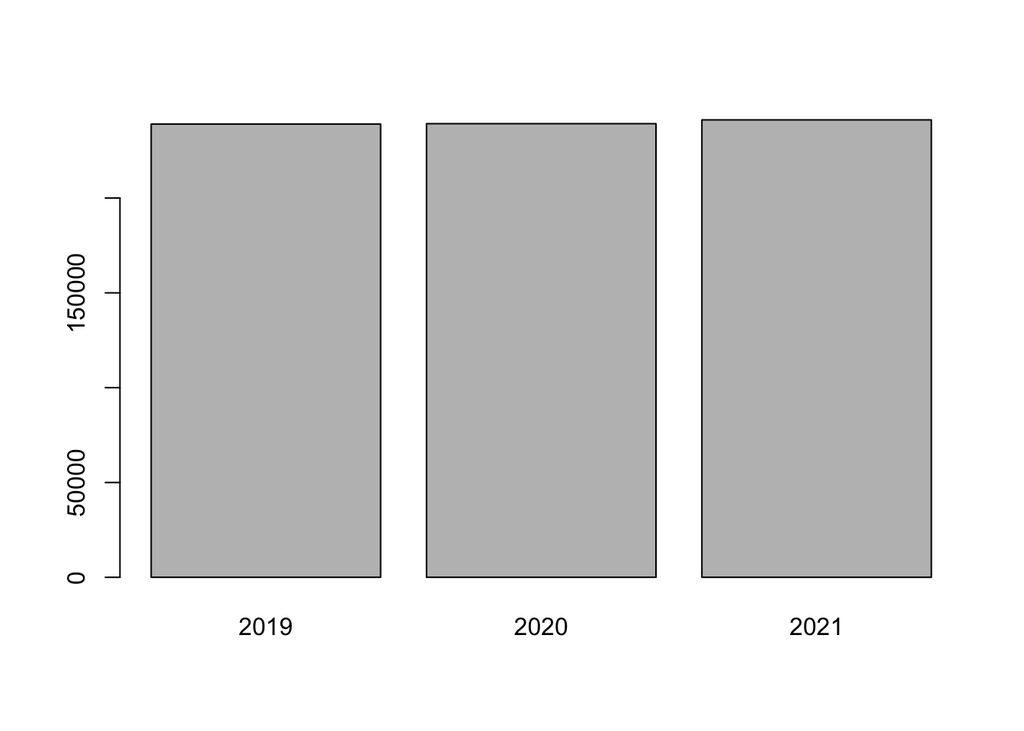

```r
sdev1 = mean(values2019)
sdev2 = mean(values2020)
sdev3 = mean(values2021)
ts = c(sdev1, sdev2, sdev3)
barplot(ts, names.arg=c('2019', '2020', '2021'))
```

It seems like the hypothesis has been falsified, there was a slight electric usage increase, but not during pandemic, instead it was after the pandemic in 2021 To investigate further why this is the case, we can add the 2022 dataset into the mix. (Note: Some datas from 2022 is missing, it’s supposed to be updated to record the 2023 dataset later)

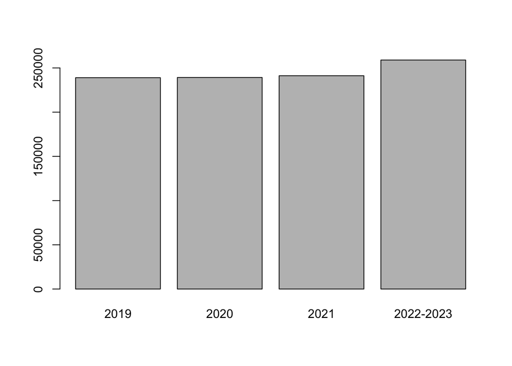

```r
values2022 <- extracted_data$`2022-R`
values2022 <- na.omit(values2022)
sdev4 <- mean(values2022)
cp <- c(sdev1, sdev2, sdev3, sdev4)
barplot(cp, names.arg=c('2019', '2020', '2021', '2022-2023'))
```

```r
print(sdev4-sdev2)
```

```
## [1] 19734.55
```

So, the first hypothesis has failed, after some more research it has found that the reason why there was an increase of electric usage from 2021 to 2022 is a complicated matter.It’s mainly caused by the fact that the energy policies are switching to one that is more suitable for wider applications of renewable energies in the power grid. However, it is also considered that as some values from the 2022-2023 dataset is missing, part of this could also contributed to this phenomenon.

## 0.4 Research question 2:

It logically makes sense that the city areas uses the most amount of electricity, since the population density in the city is much higher than other areas.

(We’ll use the latest complete dataset, which was the 2021 dataset, with the general supply column)

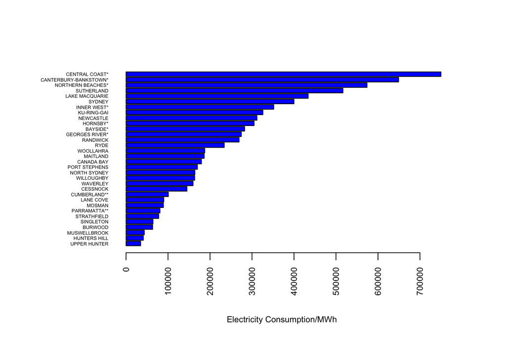

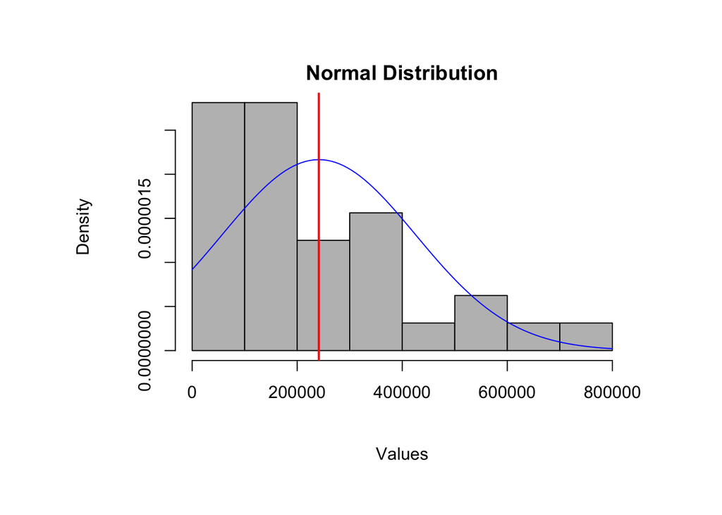

```r
distribution <- function(title, name, values){
  df <- data.frame(label=name, value=values)
  df_sorted <- df[order(df$value, decreasing = FALSE),]
  mean_val <- mean(values)
  sd_val <- sd(values)
  par(mar = c(5, 6, 2, 2), mgp = c(4, 1, 0), fig = c(0, 1, 0, 1), fin = c(6, 4))
  barplot(df_sorted$value, names.arg=wrap.labels(df_sorted$label, 20),
        col="blue", xlab=title, horiz=T, las=2, cex.names = 0.4, , cex.lab=0.7, cex.axis=0.7)
  hist(values, breaks=10, freq=FALSE, col="grey", xlab="Values", main="Normal Distribution")
  curve(dnorm(x, mean=mean_val, sd=sd_val), add=TRUE, col="blue")
  abline(v = mean_val, col = "red", lwd = 2)
}
distribution("Electricity Consumption/MWh", suburbs2021, values2021)
```

As can see, the electricity consumption of general supplies is actually skewed towards the lower end, which meant that the majority of the suburbs don’t actually uses as much compared to few areas which uses really high amounts of electricity. To see why, we can switch the target column from ‘General Supply’ to ‘Non residential large sites’ which usually spend 160 megawatts per hour

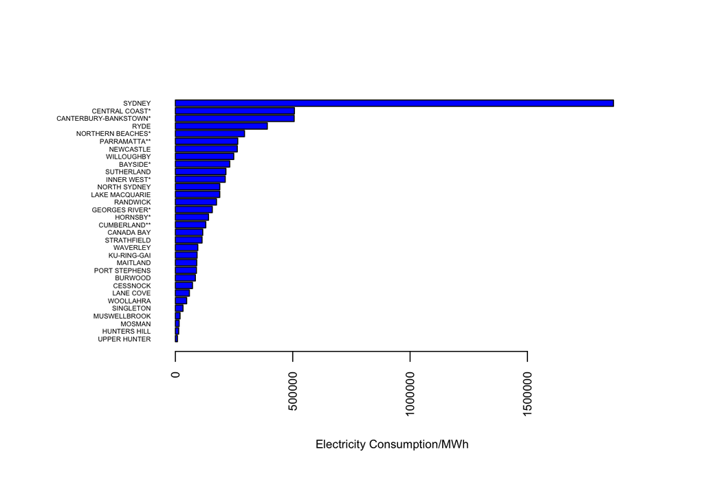

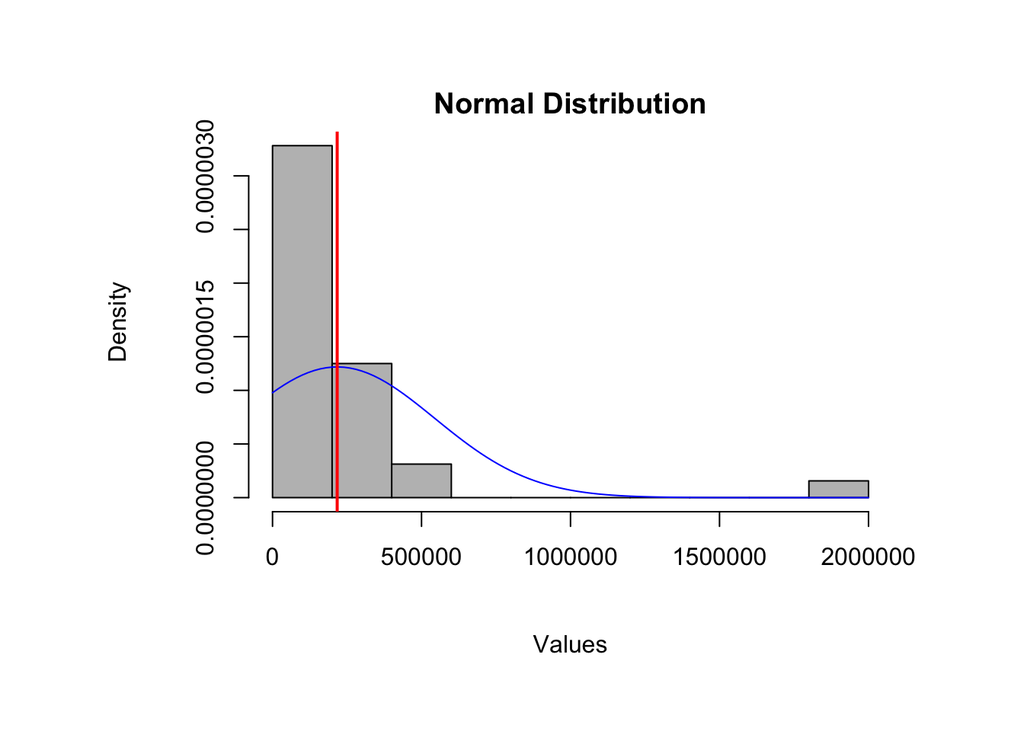

```r
values2021L <- extracted_data$`2021-L`
distribution("Electricity Consumption/MWh",suburbs2021, values2021L)
```

‘Non residential medium sites’

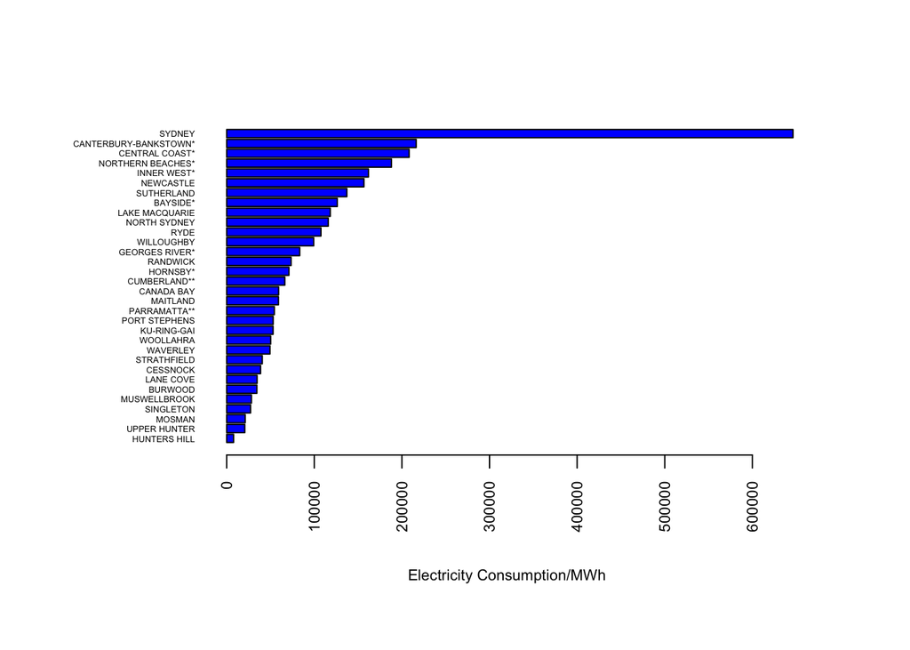

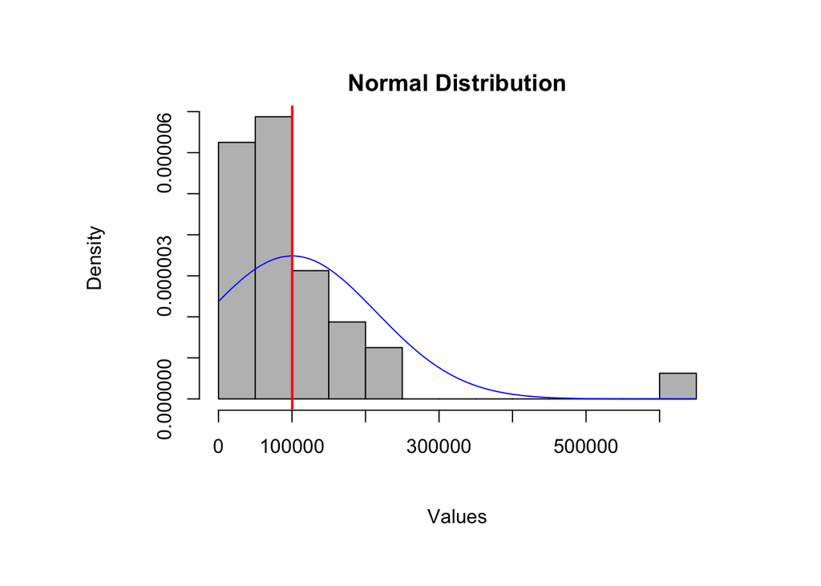

```r
values2021M <- extracted_data$`2021-M`
distribution("Electricity Consumption/MWh",suburbs2021, values2021M)
```

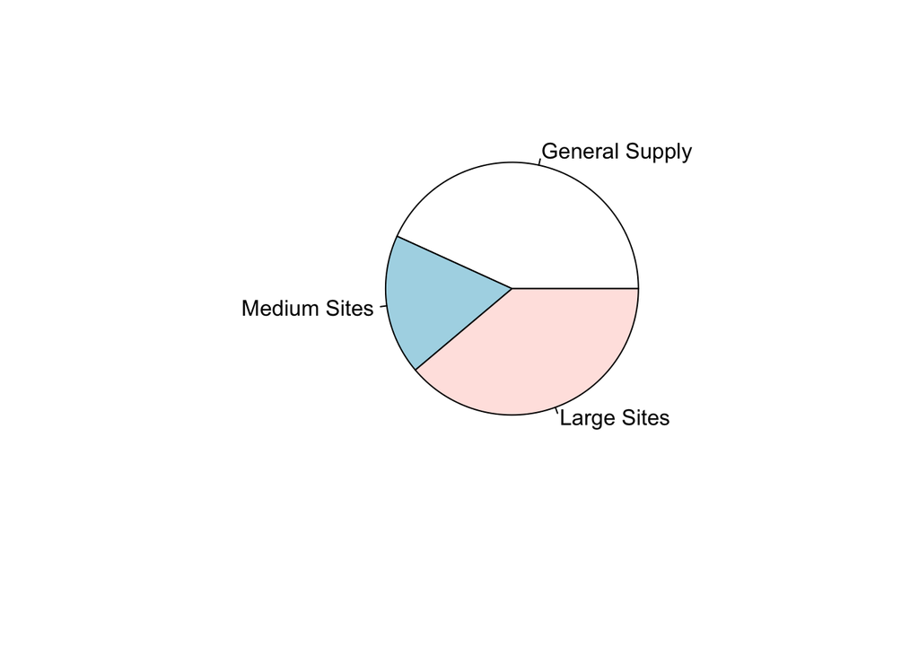

```r
par(mar = c(5, 6, 2, 2), mgp = c(4, 1, 0), fig = c(0, 1, 0, 1), fin = c(6, 4))
sum_2021G <- sum(values2021)
sum_2021M <- sum(values2021M)
sum_2021L <- sum(values2021L)
pie_values <- c(sum_2021G, sum_2021M, sum_2021L)
pie_labels <- c("General Supply", "Medium Sites", "Large Sites")
pie(pie_values, labels = pie_labels)
```

As can see, depending on what kind of electricity consumption you’re looking at, the differences between urban areas and suburban areas varies. However, the question in mind was more about residential areas.